# Final Report

Hiren Varma

April 14, 2019

```r
knitr::opts_chunk$set(echo = TRUE)
```

# link: https://github.com/hirenvarma/EDA506.git

## Final Report:

# Q1..What is change in life expectancy in last 15 years ?

# Q2 How income has improved since 2000 ?

## –Data: gapminder : It is a summary of demographics of world population broadly categorized into 6 regions like America,East Asia & Pacific, etc.

# Variables : Country- List of country , Year- data year, Life- Life expectancy , Population- Total Population ,Income - Income of country & Region- Broader Segment like continent.

# Data Expolration:

# 1.

# Subsetting data from 2000 to accomodate expectations of data

```r
gap1<- subset(gapminder, gapminder$Year>= 2000)
```

# summary of variables

summary(gap1)

# Summary of Life Expetancy, Population & Income by Region Over Years

```r
life1<-  aggregate(gap1, by=list(gap1$region, gap1$Year),
                    FUN=mean, na.rm= TRUE)
```

[output not shown]

[output cut: 520 more lines]

[output not shown]

# Plot: Overall Life Expectancy by Year

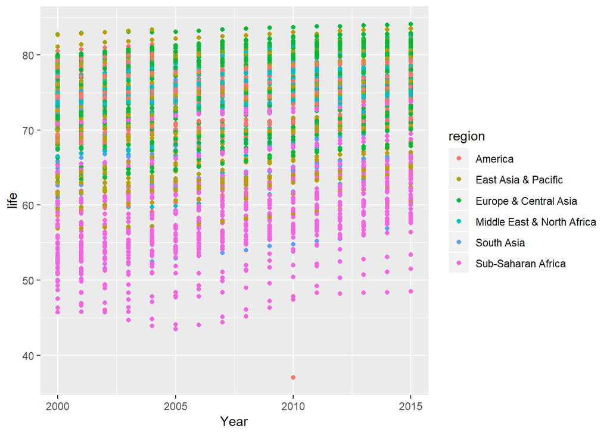

```r
ggplot(gap1, aes( Year,life, colour = region)) +
  geom_point()
```

# Summary of Income by Region Over Years

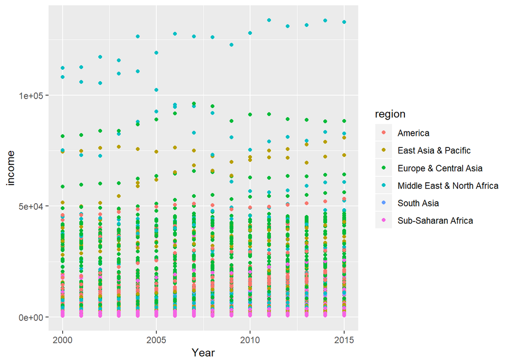

```r
ggplot(gap1, aes( Year,income, colour = region)) +
  geom_point()
```

# Summary of Population by Region Over Years

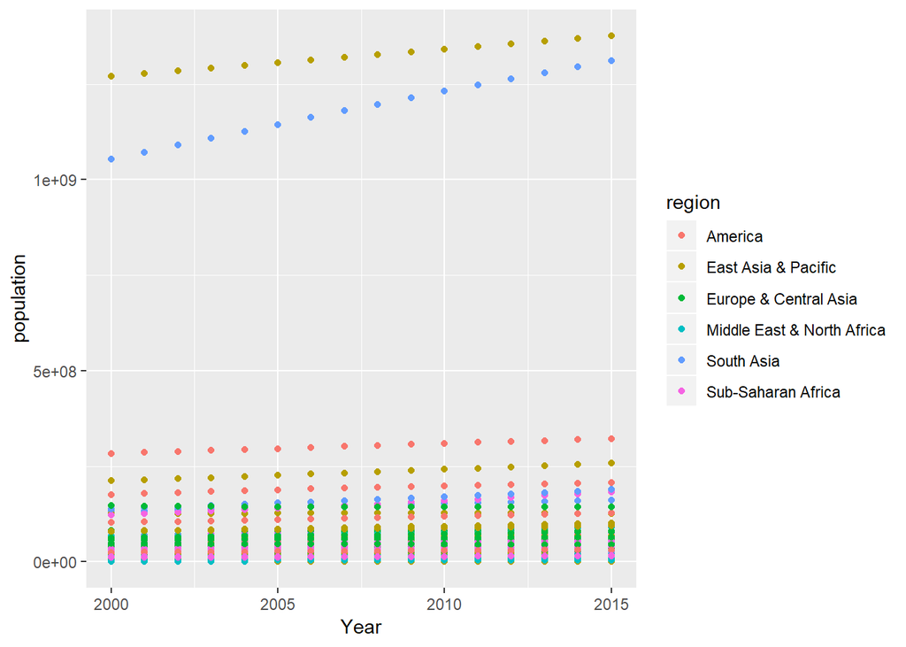

```r
ggplot(gap1, aes( Year,population, colour = region)) +
  geom_point()
```

# Creating scatterplots with regression lines for overall life expectations

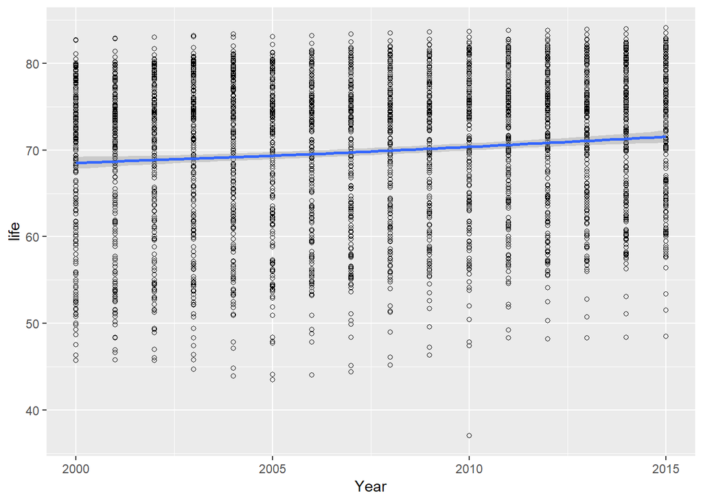

```r
ggplot(gap1, aes(x= Year, y=life)) +
     geom_point(shape=1) +    # Use hollow circles
     geom_smooth()
```

# From Regression smoothing we can see life expectancy has improced from appr. 68 to 72 from 2000 to 2015

# Regression for overall income

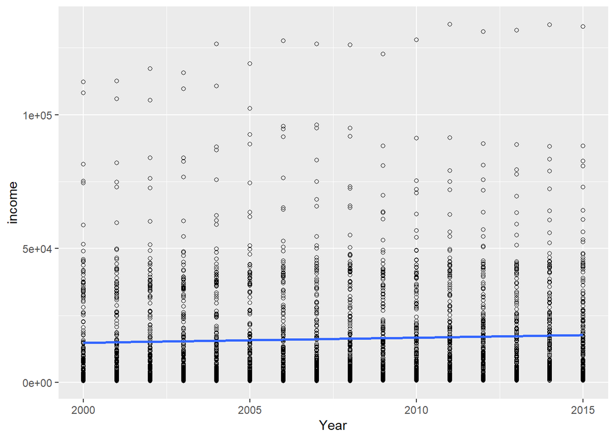

```r
ggplot(gap1, aes(x= Year, y= income)) +
    geom_point(shape=1) +    #  circles
     geom_smooth(method=lm,   #  linear regression line
                se=FALSE)    # No shaded confidence region
```

# Average Population, Life expectancy and Income by Year & Region.

```r
 aggregate(gap1,
                by = list(gap1$Year, gap1$region),
                FUN = mean, na.rm= TRUE)
```

[output not shown]

[output cut: 520 more lines]

[output not shown]

```
##    Group.1                    Group.2 Country Year     life population
## 1     2000                    America      NA 2000 73.43447   21882007
## 2     2001                    America      NA 2001 73.61692   22161719
## 3     2002                    America      NA 2002 73.79116   22432201
## 4     2003                    America      NA 2003 73.94650   22696634
## 5     2004                    America      NA 2004 74.12482   22959787
## 6     2005                    America      NA 2005 73.31290   28301478
## 7     2006                    America      NA 2006 73.50968   28630429
## 8     2007                    America      NA 2007 73.68710   28961629
## 9     2008                    America      NA 2008 73.81613   29292928
## 10    2009                    America      NA 2009 73.90000   29621019
## 11    2010                    America      NA 2010 73.15806   29943495
## 12    2011                    America      NA 2011 74.14516   30259714
## 13    2012                    America      NA 2012 74.26774   30570450
## 14    2013                    America      NA 2013 74.39355   30876396
```

[output cut: 179 more lines]

# Plot of Average Life expectancy from 2000 to 2015.

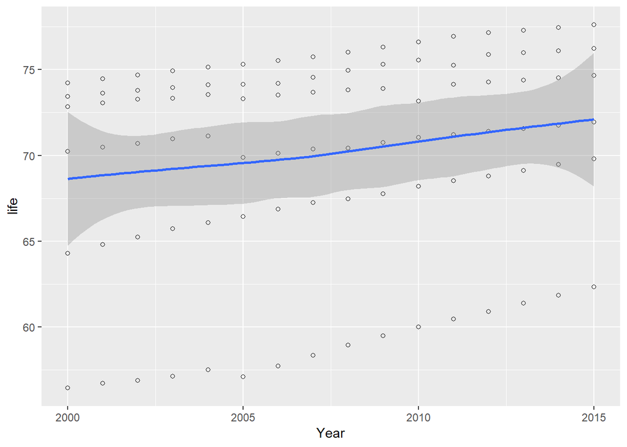

```r
 ggplot(agg1,aes(x= Year, y= life)) +
     geom_point(shape=1) +    # Use hollow circles
     geom_smooth()
```

#Overall Average Life Expectancy has improved in 15 years from Year 2000 app. 68 to 72

# Plot of Average Income from 2000 to 2015

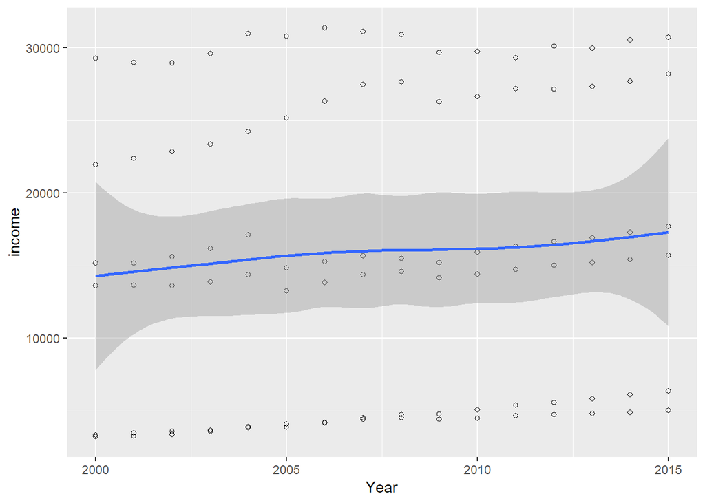

```r
 ggplot(agg1,aes(x= Year, y= income)) +
      geom_point(shape=1) +    # Use hollow circles
      geom_smooth()
```

# Overall life expectancy : Mean= 69.89, min = 37 , max= 84.10 , median = 72.2 Overall Income : Mean = 16,250 , min = 441, max = 133,734 , median = 9,028 From Regression & Scatter plots and by summary of aggregate data both Life Expectancy and Income in the population has increased in last 15 years from year 2000 to 2015.